# GBI6_ExamenFinalBioinformatica

Sthefanny Villa

18/03/2022

[output not shown]

**examen final de GBI6 - Bioinformática.**

# CONTENIDO DE LA EVALUACIÓN

Los contenidos de esta evaluación corresponden a los temas de R revisados en el curso:

- Tipos de datos
- Instalación y uso de librerías.
- Estructuras de control
- Funciones
- Manipulación de datos
- Estadística básica
- Visualización de datos

# INDICACIONES GENERALES

Esta permitido consultar todo material disponible: diapositivas, google…Sin embargo **NO** esta permitido consultar a sus colegas.

Ustedes estan utilizando el R Markdown. Las instruciones son:

- Creen una carpeta en su computador con el nombre “GBI6_ExamenFinal” donde guarden este cuaderno .Rmd.
- Cree un subdirectorio de nombre “data” donde guarde la data que van a utilizar.
- Cree un subdirectorio de nombre “results” donde guarde la tablas y figuras generadas del análisis.
- Definan a esa carpeta como su directorio de trabajo.
- Arriba, **solamente** donde dice “author”, deben llenar sus nombres.
- Los codigos deben ser escritos dentro de las cajas que inician y terminan con ``` o dentro de las cajas indicadas abajo de las preguntas.
- Al final del examen deben utilizar el comando “Knit” para generar un archivo .html
- Es recomendable crear una copia de este script guía.
- Genere controles de la versión para cada una de las preguntas con la leyenda “Nombre Apellido, resuelve el ejercicio XX”.
- Copie y peque la dirección de su repositorio de GitHub en la actividad **“ExamenFinal”**.
- Asegúrese de responder explícitamente cada una de las preguntas.

Para comprender la data de esta evaluación se requiere conocer el significado de algunos acrónimos de los tipos de cancer como indica el [Broad Institute Cancer Names](https://gdac.broadinstitute.org/). Asimismo revise la información de ayuda para `expresionsTCGA`. La data contiene las columnas:

- **bcr_patient_barcode**: es el identificador del paciente.
- **dataset**: es el identificador del tipo de cancer del paciente.
- **resto de columnas**: nivees de expresión de los diferentes mRNA de los genes que están como nombre de columna (para este análisis se han seleccionado solamente 7 de ellos).

# PREGUNTAS

## **Pregunta 1: MANIPULACIÓN DE DATOS [4 PUNTOS]**

### [0.5 PUNTOS] 1.1 Defina su directorio de trabajo.

```r
getwd()
```

```
## [1] "C:/Users/Asus/Documents/CSB/GBI6_ExamenFinal"
```

```r
setwd("/Users/Asus/Documents/CSB/GBI6_ExamenFinal/")
```

### [0.5 PUNTOS] 1.2. Cargue la data “mRNA_expr.csv”

```r
df <- read.csv("data/mRNA_expr.csv")
library(readxl)
head(df)
```

```
##   bcr_patient_barcode dataset     GATA3      PTEN      XBP1      ESR1      MUC1
## 1               BRCA1    BRCA  2.870500 1.3613571  2.983333  3.084250  1.652125
## 2               BRCA2    BRCA  2.166250 0.4283571  2.550833  2.386000  3.080250
## 3               BRCA3    BRCA  1.323500 1.3056429  3.020417  0.791250  2.985250
## 4               BRCA4    BRCA  1.841625 0.8096429  3.131333  2.495417 -1.918500
## 5               BRCA5    BRCA -6.025250 0.2508571 -1.451750 -4.860667 -1.171500
## 6               BRCA6    BRCA  1.804500 1.3107857  4.041083  2.797000  3.529750
##          FN1       GAPDH
## 1  1.7333750 -1.62916667
## 2  0.2176250 -0.95116667
## 3  2.5080833 -1.29883333
## 4 -0.2197083 -0.82066667
## 5 -0.4773750  1.29458333
## 6  1.2454583 -0.05216667
```

### [1 PUNTO] 1.3 Cree una función de nombre `long_df` para transformar la data `df` de la forma wide a long.

```r
# Escriba aquí la función long_df

library(tidyr)
library(dplyr)
long_df <- function(df) {
  df$dataset <- as.factor(df$dataset)
  df_longer <- gather(df, gen, expresion_level, GATA3, PTEN, XBP1, ESR1, MUC1, FN1, GAPDH, factor_key=TRUE)
  df_longer1 <- select(df_longer, -bcr_patient_barcode)
  return (df_longer1)
}
```

### [1 PUNTO] 1.4 Genere la data `df_long` utilizandola función `long_df`.

La tabla resultante tendrá tres columnas: `dataset, gen, expresion_level`.

```r
# Genere la data df_long con la funcion creada y seleccionar las columnas de interes
df_long <- long_df(df)
Datos <- df_long %>% group_by(gen)
Datos
```

```
## # A tibble: 10,241 x 3
## # Groups:   gen [7]
##    dataset gen   expresion_level
##    <fct>   <fct>           <dbl>
##  1 BRCA    GATA3           2.87
##  2 BRCA    GATA3           2.17
##  3 BRCA    GATA3           1.32
##  4 BRCA    GATA3           1.84
##  5 BRCA    GATA3          -6.03
##  6 BRCA    GATA3           1.80
##  7 BRCA    GATA3          -4.88
##  8 BRCA    GATA3          -3.14
##  9 BRCA    GATA3           2.03
## 10 BRCA    GATA3          -0.293
## # ... with 10,231 more rows
```

```r
head(df_long)
```

```
##   dataset   gen expresion_level
## 1    BRCA GATA3        2.870500
## 2    BRCA GATA3        2.166250
## 3    BRCA GATA3        1.323500
## 4    BRCA GATA3        1.841625
## 5    BRCA GATA3       -6.025250
## 6    BRCA GATA3        1.804500
```

### [0.5 PUNTOS] 1.5 A partir de la data `df_long`, genere un **Descriptive table** (librería `sjPlot`) y guárdelo en el subdirectorio “result” con el nombre **mRNA_expr_summary.doc** (previamente debe seleccionar las celdas adecuadas con funciones de la librería `dplyr` en conjunto con el operador `%>%`).

```r
library(sjmisc)
```

```r
library(sjPlot)
library(dplyr)
cancermama <- Datos %>% group_by(gen) %>% mutate(row = row_number()) %>%
  tidyr::pivot_wider(names_from = gen, values_from = expresion_level) %>%
  select(-row)
descr(cancermama) %>% tab_df(title = "Descripcion del cancer de mama",
                             file = "C:/Users/ASUS/Documents/CSB/GBI6_ExamenFinal/results/mRNA_expr_summary.doc")
```

Descripcion del cancer de mama

| var | type | label | n | NA.prc | mean | sd | se | md | trimmed | range | iqr | skew |
| --- | --- | --- | --- | --- | --- | --- | --- | --- | --- | --- | --- | --- |
| dataset | categorical | dataset | 1463 | 0 | 3.12 | 1.91 | 0.05 | 4.00 | 3.10 | 5 (1-6) | 4.00 | -0.06 |
| GATA3 | numeric | GATA3 | 1463 | 0 | -2.00 | 2.87 | 0.07 | -3.50 | -2.19 | 9.96 (-6.03-3.93) | 5.59 | 0.57 |
| PTEN | numeric | PTEN | 1463 | 0 | 0.60 | 0.74 | 0.02 | 0.70 | 0.65 | 5.55 (-2.75-2.8) | 0.88 | -0.82 |
| XBP1 | numeric | XBP1 | 1463 | 0 | 0.23 | 1.74 | 0.05 | -0.18 | 0.16 | 8.05 (-3.32-4.74) | 2.91 | 0.39 |
| ESR1 | numeric | ESR1 | 1463 | 0 | 1.09 | 2.63 | 0.07 | 1.66 | 1.22 | 11.31 (-5.2-6.11) | 4.09 | -0.49 |
| MUC1 | numeric | MUC1 | 1463 | 0 | 1.74 | 1.45 | 0.04 | 2.06 | 1.87 | 7.89 (-3.32-4.56) | 1.91 | -0.77 |
| FN1 | numeric | FN1 | 1463 | 0 | -0.89 | 1.44 | 0.04 | -0.91 | -0.91 | 7.3 (-4.06-3.23) | 2.40 | 0.11 |
| GAPDH | numeric | GAPDH | 1463 | 0 | -0.97 | 0.68 | 0.02 | -1.02 | -0.99 | 5.12 (-3.12-2) | 0.90 | 0.27 |

## **Pregunta 2 VISUALIZACION DE DATOS [5 PUNTOS]**

Para esta pregunta tiene que utilizar la data `df_long`.

### [1 PUNTO] 2.1 Cree la funcion `tcga_boxplots` para visualizar boxplots y jitterplots. El único parámetro de la función es `dataset`. La función debe crear un boxplot de los niveles de expresión para cada gen.

```r
# Escriba el código para crear la función tcga_boxplots
library(ggplot2)
## creamos la función tcga_plots que necesita un parametro tipo data frame y como output devuelta una lista de graficos de los genes y su diferentes niveles de expresion
tcga_boxplots <- function(dataset) {
  return(ggplot (dataset, aes(x = gen, y = expresion_level, col = gen)) + labs(x="Gen", y = "Expression Level") + geom_boxplot() + geom_jitter(size=0.2))
}
head(tcga_boxplots)
```

```
##
## 1 function (dataset)
## 2 {
## 3     return(ggplot(dataset, aes(x = gen, y = expresion_level,
## 4         col = gen)) + labs(x = "Gen", y = "Expression Level") +
## 5         geom_boxplot() + geom_jitter(size = 0.2))
## 6 }
```

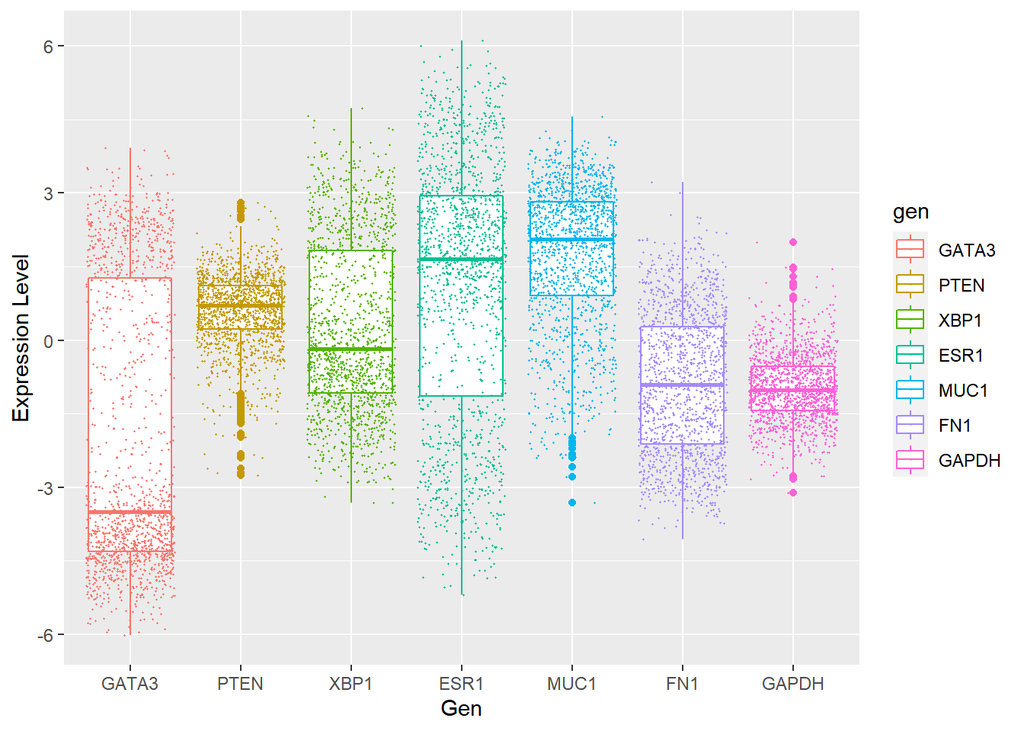

```r
plot(tcga_boxplots(df_long))
```

```r
ggsave("C:/Users/ASUS/Documents/CSB/GBI6_ExamenFinal/results/GENES Y NIVELES.png", width = 6, height = 8, dpi = 300)
```

### [0.5 PUNTOS] 2.2 Utilizando la función `lapply()` genera la lista `cancertype_boxplots` con las gráficas para cada tipo de cancer (cada tipo de dataset).

```r
# Escriba el código para generar la lista.
cancer <- list(BRCA <- filter(df_long, dataset == "BRCA"), OV <- filter(df_long, dataset == "OV"), LUSC <- filter(df_long, dataset == "LUSC"), KIPAN <- filter(df_long, dataset == "KIPAN"), KIRP <- filter(df_long, dataset == "KIRP"), UCEC <- filter(df_long, dataset == "UCEC")
)
cancertype_boxplots = lapply(cancer, function(x) {ggplot(x, aes(dataset, expresion_level, col = dataset)) +
    geom_boxplot() + theme(legend.position='none') + labs(x = "", y = "Expression level")})
ggsave("C:/Users/ASUS/Documents/CSB/GBI6_ExamenFinal/results/IMAGEN 2_2.png", width = 6, height = 8, dpi = 300)
```

### [0.5 PUNTOS] 2.3 Guarde en el subdirectorio `result` el tercer plot de la lista `cancertype_boxplots` con el nombre `boxplot3.png`. La definición de a figura debe ser de 300dpi.

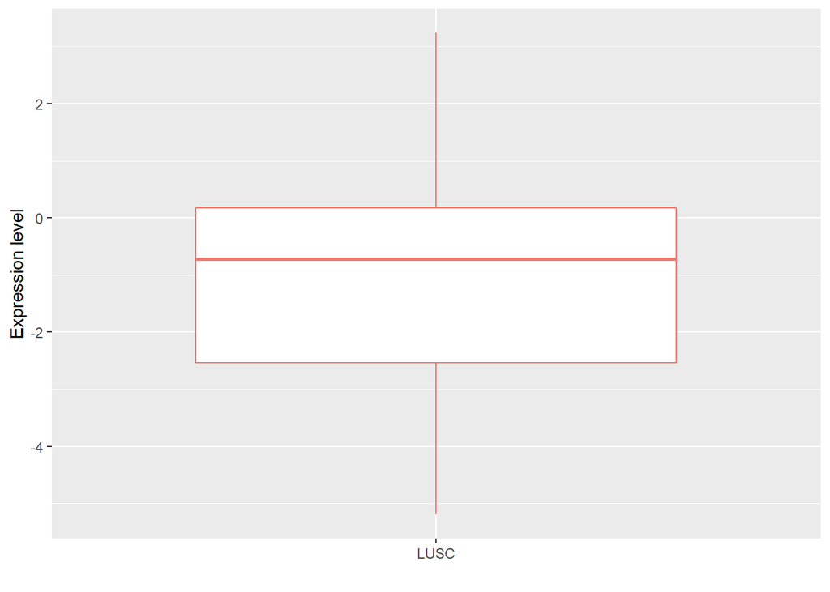

```r
# Escriba el código para guardar la tercera figura de la lista.
cancertype_boxplots[3]
```

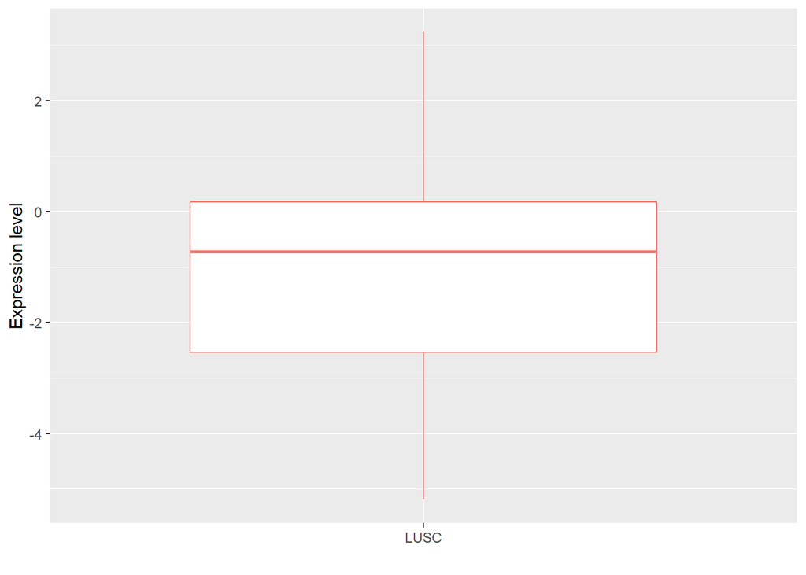

```r
ggsave("boxplot3.png",device="png",path="results",width=20, height=20,units='cm',dpi = 300)
#or
cancertype_boxplots[3]
```

```r
ggsave("C:/Users/ASUS/Documents/CSB/GBI6_ExamenFinal/results/boxplot3.png", width = 6, height = 8, dpi = 300)
```

### [1 PUNTO] 2.4 Escriba la función `reg_gen_expression`, con el parámetro `gen`. En este caso la función visualizará una gráfica de nube de puntos (geom_point) y una regresión por tipo de “dataset”. La gráfica será de comparación de gen1 con gen2; por ejemplo en el eje “x” `GATA3` y en el eje “y”” `FN1`.

```r
# Escriba aquí su función reg_gen_expression
r_gen_expression <- list(
    BRCA <- filter(df_long, dataset == "BRCA"),
    OV <- filter(df_long, dataset == "OV"),
    LUSC <- filter(df_long, dataset == "LUSC"),
    KIPAN <- filter(df_long, dataset == "KIPAN"),
    KIRP <- filter(df_long, dataset == "KIRP"),
    UCEC <- filter(df_long, dataset == "UCEC"),
    GAPDH <- filter(df_long, dataset == "GAPDH")
  )

plots_cancer <- list (
  BRCA_1 <- BRCA %>% group_by(gen) %>% mutate(row = row_number()) %>%
    tidyr::pivot_wider(names_from = gen, values_from = expresion_level) %>%
    select(-row),
  OV_1 <- OV %>% group_by(gen) %>% mutate(row = row_number()) %>%
    tidyr::pivot_wider(names_from = gen, values_from = expresion_level) %>%
    select(-row),
  LUSC_1 <- LUSC %>% group_by(gen) %>% mutate(row = row_number()) %>%
    tidyr::pivot_wider(names_from = gen, values_from = expresion_level) %>%
    select(-row),
  KIPAN_1 <- KIPAN %>% group_by(gen) %>% mutate(row = row_number()) %>%
    tidyr::pivot_wider(names_from = gen, values_from = expresion_level) %>%
    select(-row),
  KIRP_1 <- KIRP %>% group_by(gen) %>% mutate(row = row_number()) %>%
    tidyr::pivot_wider(names_from = gen, values_from = expresion_level) %>%
    select(-row),
  UCEC_1 <- UCEC %>% group_by(gen) %>% mutate(row = row_number()) %>%
    tidyr::pivot_wider(names_from = gen, values_from = expresion_level) %>%
    select(-row),
  GAPH_1 <- UCEC %>% group_by(gen) %>% mutate(row = row_number()) %>%
    tidyr::pivot_wider(names_from = gen, values_from = expresion_level) %>%
    select(-row)
)
plots_cancer
```

```
## [[1]]
## # A tibble: 590 x 8
##    dataset  GATA3   PTEN   XBP1   ESR1    MUC1    FN1   GAPDH
##    <fct>    <dbl>  <dbl>  <dbl>  <dbl>   <dbl>  <dbl>   <dbl>
##  1 BRCA     2.87   1.36   2.98   3.08   1.65    1.73  -1.63
##  2 BRCA     2.17   0.428  2.55   2.39   3.08    0.218 -0.951
##  3 BRCA     1.32   1.31   3.02   0.791  2.99    2.51  -1.30
##  4 BRCA     1.84   0.810  3.13   2.50  -1.92   -0.220 -0.821
##  5 BRCA    -6.03   0.251 -1.45  -4.86  -1.17   -0.477  1.29
##  6 BRCA     1.80   1.31   4.04   2.80   3.53    1.25  -0.0522
##  7 BRCA    -4.88  -0.237 -0.725 -4.49  -1.46   -1.97  -0.777
##  8 BRCA    -3.14  -1.24  -1.19  -1.63  -0.987  -0.459  1.08
##  9 BRCA     2.03   1.21   2.28   4.12   0.668   0.766 -2.01
## 10 BRCA    -0.293  0.288 -1.61   0.473  0.0115 -0.260 -0.243
## # ... with 580 more rows
##
## [[2]]
## # A tibble: 561 x 8
##    dataset GATA3   PTEN    XBP1  ESR1  MUC1     FN1   GAPDH
##    <fct>   <dbl>  <dbl>   <dbl> <dbl> <dbl>   <dbl>   <dbl>
##  1 OV      -3.46  0.816 -0.603  3.04   2.66 -2.05   -1.68
##  2 OV      -3.69  0.864  0.929  3.11   2.14 -2.25   -1.54
##  3 OV      -3.81  0.882 -0.0015 2.60   2.73 -2.02   -1.79
##  4 OV      -4.35 -1.90  -1.01   2.30   1.92  0.0710 -0.817
##  5 OV      -4.53  0.786  0.161  1.85   1.86 -0.307  -1.25
##  6 OV      -3.88 -0.537 -0.902  1.55   2.89 -2.70   -1.94
##  7 OV      -3.45  0.599 -1.06   2.59   2.75 -2.54   -1.53
##  8 OV      -4.25  0.827 -1.52   1.65   3.22  0.987  -2.06
##  9 OV      -3.15  0.653 -0.978  0.666  2.64  1.13   -1.04
## 10 OV      -4.25  0.548 -1.08   2.51   3.20 -1.57    0.0429
## # ... with 551 more rows
##
## [[3]]
## # A tibble: 154 x 8
##    dataset  GATA3    PTEN    XBP1   ESR1     MUC1    FN1  GAPDH
##    <fct>    <dbl>   <dbl>   <dbl>  <dbl>    <dbl>  <dbl>  <dbl>
##  1 LUSC    -3.66  -0.252   0.876  -0.806  0.849   -0.822 -0.376
##  2 LUSC    -4.77   0.0888  0.528  -3.01   1.17     0.464 -0.580
##  3 LUSC    -4.48   0.568  -0.0235 -4.14   0.661   -1.36  -0.776
##  4 LUSC    -0.552  1.06   -0.715  -3.04   0.0321   1.29  -0.603
```

[output cut: 61 more lines]

```
## [[7]]
## # A tibble: 54 x 8
##    dataset GATA3    PTEN    XBP1   ESR1   MUC1    FN1     GAPDH
##    <fct>   <dbl>   <dbl>   <dbl>  <dbl>  <dbl>  <dbl>     <dbl>
##  1 UCEC    -4.91  0.731   0.131  -3.12   2.06  -1.39  -0.215
##  2 UCEC    -5.54  0.593  -2.52   -0.152  1.49  -1.70  -0.779
##  3 UCEC    -3.30  0.369   0.630  -2.42   2.69  -0.950 -0.502
##  4 UCEC    -4.73 -0.740   0.151   2.59   4.03  -1.17  -0.523
##  5 UCEC    -4.72 -1.35    1.25    2.88   1.28  -3.28  -0.000917
##  6 UCEC    -4.25  0.382  -1.16    2.97   0.607 -2.30  -0.392
##  7 UCEC    -4.04 -0.668  -0.711  -1.48  -0.426 -1.94   0.0188
##  8 UCEC    -4.83 -0.355  -0.796   3.34   1.64  -2.54  -0.748
##  9 UCEC    -4.11 -0.0284  0.0528  3.47   2.46  -3.07  -0.368
## 10 UCEC    -5.05  1.61    1.22    4.39   2.74  -3.10  -0.952
## # ... with 44 more rows
```